# Math 189: Time Series II

# Time Series Regression and Autoregression

- It is tempting to regress time series data on time $t=1, \ldots, n$, as a covariate. Rarely does this provide satisfactory results (when used alone).

## Regression on Time Trend

- Regression model with time trend:
  $$X_t = \beta_0 + \beta_1 t + Z_t.$$
  Is $\{ Z_t \}$ i.i.d.? Usually: **No**.

### Example: U.S. Population

- Try out time trend regression for U.S. population.

```r
pop <- read.table("USpop.dat")
pop <- ts(pop, start = 1901)
n <- length(pop)
time <- seq(1,n)
model1 <- lm(pop ~ time)
summary(model1)
```

```
##
## Call:
## lm(formula = pop ~ time)
##
## Residuals:
##       Min        1Q    Median        3Q       Max
## -14549597  -4786782   1606479   4952580  10891620
##
## Coefficients:
##             Estimate Std. Error t value Pr(>|t|)
## (Intercept) 63186029    1432136   44.12   <2e-16 ***
## time         2016351      24868   81.08   <2e-16 ***
## ---
## Signif. codes:  0 '***' 0.001 '**' 0.01 '*' 0.05 '.' 0.1 ' ' 1
##
## Residual standard error: 7071000 on 97 degrees of freedom
## Multiple R-squared:  0.9855, Adjusted R-squared:  0.9853
## F-statistic:  6575 on 1 and 97 DF,  p-value: < 2.2e-16
```

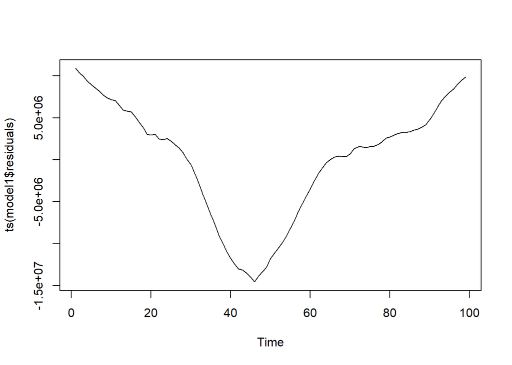

```r
plot(ts(model1$residuals))
```

- Highly structured residuals! We could add higher order polynomial effects to time trend, but it won’t really help.

## Regression on Past of Self

- Let past values of the time series be the covariates. Called *Autoregression*.
- Autoregressive model:
  $$X_t = \rho \, X_{t-1} + Z_t.$$
  Assume $\{ Z_t \}$ i.i.d.

### Example: U.S. Population

- Try out autoregression for U.S. population.

```r
model2 <- lm(pop[-1] ~ pop[-n])
summary(model2)
```

```
##
## Call:
## lm(formula = pop[-1] ~ pop[-n])
##
## Residuals:
##      Min       1Q   Median       3Q      Max
## -1025866  -289498   -73620   301639  1164336
##
## Coefficients:
##              Estimate Std. Error  t value Pr(>|t|)
## (Intercept) 9.705e+05  1.522e+05    6.376 6.33e-09 ***
## pop[-n]     1.006e+00  8.814e-04 1141.752  < 2e-16 ***
## ---
## Signif. codes:  0 '***' 0.001 '**' 0.01 '*' 0.05 '.' 0.1 ' ' 1
##
## Residual standard error: 499900 on 96 degrees of freedom
## Multiple R-squared:  0.9999, Adjusted R-squared:  0.9999
## F-statistic: 1.304e+06 on 1 and 96 DF,  p-value: < 2.2e-16
```

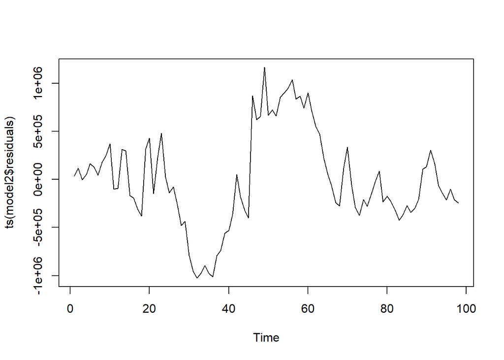

```r
plot(ts(model2$residuals))
```

- Residuals are less structured, though maybe still not i.i.d.
- Why does this seem to work?

```r
cor(pop[-1],pop[-n])
```

```
## [1] 0.9999632
```

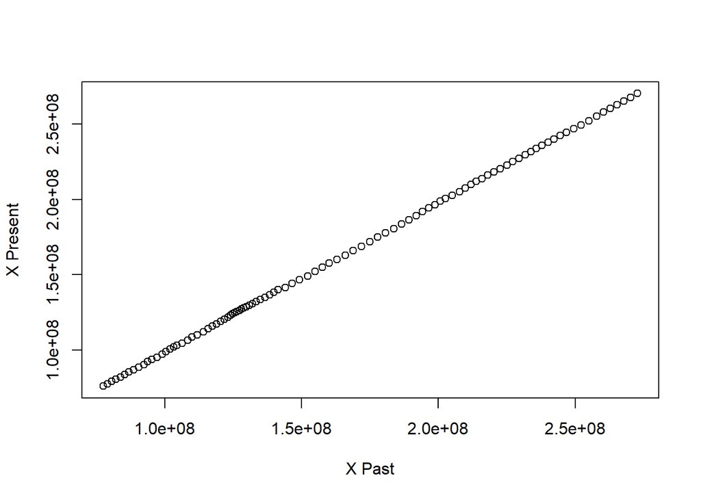

```r
plot(pop[-1],pop[-n],xlab="X Past",ylab="X Present")
```

## Incorporate Time Trend

- We can incorporate time trend into an autoregression.
- Do not do it this way
  $$X_t = \rho X_{t-1} + \beta_0 + \beta_1 t + Z_t,$$
  since this makes the mean ${\mathbf E} [ X_t ]$ depend on $\rho$.
- Instead, set up the model this way:
  $$\begin{align*}
  Y_t & = \beta_0 + \beta_1 t + X_t \\
  X_t & = \rho \, X_{t-1} + Z_t.
  \end{align*}$$

```r
model3 <- lm(pop[-1] ~ pop[-n] + time[-1])
summary(model3)
```

```
##
## Call:
## lm(formula = pop[-1] ~ pop[-n] + time[-1])
##
## Residuals:
##      Min       1Q   Median       3Q      Max
## -1094117  -273594   -31978   350442  1023219
##
## Coefficients:
##              Estimate Std. Error t value Pr(>|t|)
## (Intercept) 1.636e+06  4.538e+05   3.606 0.000498 ***
## pop[-n]     9.952e-01  7.201e-03 138.202  < 2e-16 ***
## time[-1]    2.269e+04  1.458e+04   1.556 0.122985
## ---
## Signif. codes:  0 '***' 0.001 '**' 0.01 '*' 0.05 '.' 0.1 ' ' 1
##
## Residual standard error: 496200 on 95 degrees of freedom
## Multiple R-squared:  0.9999, Adjusted R-squared:  0.9999
## F-statistic: 6.615e+05 on 2 and 95 DF,  p-value: < 2.2e-16
```

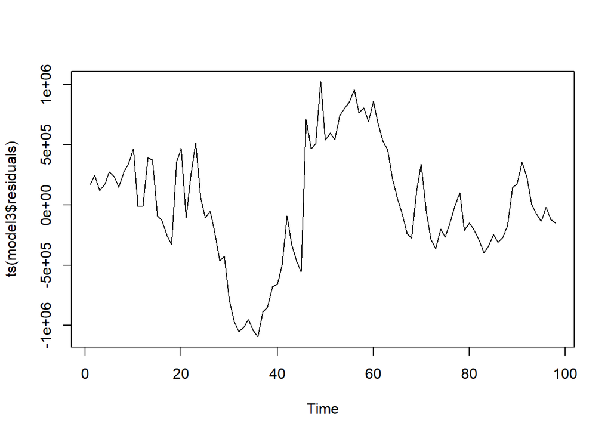

```r
plot(ts(model3$residuals))
```

- Notice slope coefficient $\beta_1$ is not significant, and residuals resemble those of the pure autoregressive model. So not much benefit to using time covariate.

# The AR(1) Process

## Defining the Process

- Let $Z_t \sim \mbox{i.i.d.} (0,\sigma^2)$ and $\{ X_t \}$ defined via
  $$X_t = \phi \, X_{t-1} + Z_t$$
  for $t \geq 1$, where $|\phi| < 1$.
- This is a recursion, called an *order 1 autoregression*, or AR(1).
- How to define $X_0$? If $X_0 \sim (0, \sigma^2/(1-\phi^2) )$, then $\mbox{Var} [X_t] = \mbox{Var}[ X_{t-1}]$!
- This is an example of **stationarity** of a process.

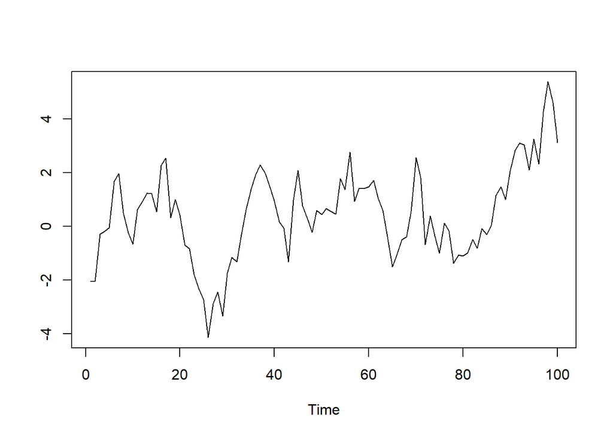

```r
n <- 100
set.seed(123)
z <- rnorm(n)
x <- rep(0,n)
phi <- .9
x0 <- rnorm(1)/sqrt(1-phi^2)
x[1] <- phi*x0 + z[1]
for(t in 2:n) { x[t] <- phi*x[t-1] + z[t] }
plot(ts(x),xlab="Time",ylab="")
```

## What is the Mean?

- Suppose we put a constant in the autoregression:
  $$X_t = \mu + \phi \, X_{t-1} + Z_t.$$
- Then the mean is
  $${\mathbb E} [ X_t ] = \mu + \phi \, {\mathbb E} [ X_{t-1} ].$$
- If we assume *stationarity*, that the mean and variance don’t depend on time $t$, then
  $${\mathbb E} [ X ] = \mu + \phi \, {\mathbb E} [ X ].$$
  This implies that
  $${\mathbb E} [ X ] = \frac{\mu}{1 - \phi}.$$
- So putting a constant $\mu$ in the regression is **not** the mean; we have to divide by $1 - \phi$ to get the mean.

## Fitting to Data

- Code the autoregression using linear regression.

```r
ar_mdl1 <- lm(x[-1] ~ x[-n] -1)
summary(ar_mdl1)
```

```
##
## Call:
## lm(formula = x[-1] ~ x[-n] - 1)
##
## Residuals:
##      Min       1Q   Median       3Q      Max
## -2.23871 -0.44521  0.04144  0.69570  2.27754
##
## Coefficients:
##       Estimate Std. Error t value Pr(>|t|)
## x[-n]  0.86119    0.05319   16.19   <2e-16 ***
## ---
## Signif. codes:  0 '***' 0.001 '**' 0.01 '*' 0.05 '.' 0.1 ' ' 1
##
## Residual standard error: 0.9178 on 98 degrees of freedom
## Multiple R-squared:  0.7279, Adjusted R-squared:  0.7251
## F-statistic: 262.1 on 1 and 98 DF,  p-value: < 2.2e-16
```

```r
ar_mdl2 <- ar.ols(x,order=1,aic=FALSE)
ar_mdl2$ar[,1,1]
```

```
## [1] 0.8428458
```

```r
ar_mdl2$x.mean
```

```
## [1] 0.4763583
```

```r
ar_mdl2$var.pred
```

```
## [1] 0.8197486
```

- Another method is *Yule-Walker*, which is based on estimating so-called *autocovariances*.

```r
ar_mdl3 <- ar.yw(x,order=1,aic=FALSE)
ar_mdl3$ar
```

```
## [1] 0.8216754
```

```r
ar_mdl3$x.mean
```

```
## [1] 0.4763583
```

```r
ar_mdl3$var.pred
```

```
## [1] 0.9438374
```

# The AR(p) Process

## Defining the Process

- Let $Z_t \sim \mbox{i.i.d.} (0,\sigma^2)$ and $\{ X_t \}$ defined via
  $$X_t = \phi_1 \, X_{t-1} + \ldots + \phi_p \, X_{t-p} + Z_t$$
  for $t \geq 1$.
- The coefficients $\phi_1,\ldots, \phi_p$ satisfy complicated *stability conditions*.
- This is a recursion, called an *order p autoregression*, or AR(p).
- There is also a stationary initialization involving the first $p$ observations, but this is covered in a full time series course.

## Simulation

- We can initialize with zeroes and utilize *burn-in*, which refers to an initial stretch of the simulation that is later discarded.
- Here is an example of an AR(2) with cyclic structure.

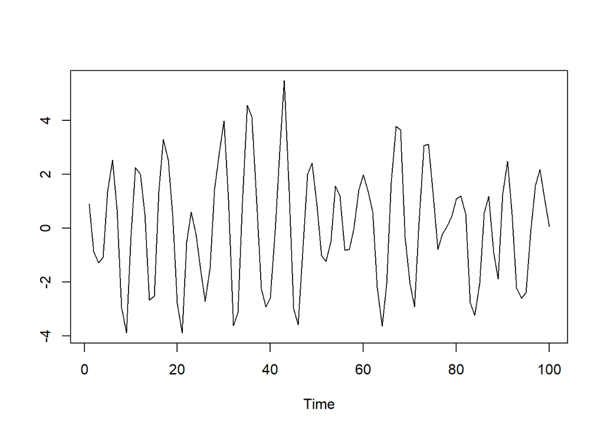

```r
n <- 100
burn <- 500
set.seed(444)
z <- rnorm(n+burn)
x <- rep(0,n+burn)
phi <- c(.9,-.81)
for(t in 3:(n+burn)) { x[t] <- phi[1]*x[t-1] + phi[2]*x[t-2] + z[t] }
x <- x[(burn+1):(burn+n)]
plot(ts(x),xlab="Time",ylab="")
```

## Fitting

- If we want to fit an AR model, what order should we use?
- We could try resampling techniques, but they don’t work so well with time series (unless they are modified).
- It is popular to use *information criteria*, which balance model fit against the number of model parameters.
- There is an information criterion (called AIC, for Akaike Information Criterion) in R.

```r
ar_mdl <- ar.ols(x)
ar_mdl$order
```

```
## [1] 2
```

```r
ar_mdl$ar[,1,1]
```

```
## [1]  0.9846621 -0.8439875
```

```r
ar_mdl$x.mean
```

```
## [1] 0.05084741
```

```r
ar_mdl$var.pred
```

```
## [1] 0.9640433
```